# Notebook

[Sebastian Raschka](http://sebastianraschka.com)

- [Open in IPython nbviewer](http://nbviewer.ipython.org/github/rasbt/One-Python-benchmark-per-day/blob/master/ipython_nbs/day17_numpy_stacking.ipynb)
- [Link to this IPython notebook on Github](https://github.com/rasbt/One-Python-benchmark-per-day/blob/master/ipython_nbs/day17_numpy_stacking.ipynb)
- [Link to the GitHub Repository One-Python-benchmark-per-day](https://github.com/rasbt/One-Python-benchmark-per-day)

```python
%load_ext watermark
```

```python
%watermark -d -v -u -t -z -p numpy
```

```
Last updated: 05/07/2014 18:39:56 EDT

CPython 3.4.1
IPython 2.1.0

numpy 1.8.1
```

[More information](http://nbviewer.ipython.org/github/rasbt/python_reference/blob/master/ipython_magic/watermark.ipynb) about the `watermark` magic command extension.

I would be happy to hear your comments and suggestions.  
Please feel free to drop me a note via [twitter](https://twitter.com/rasbt), , or [google+](https://plus.google.com/+SebastianRaschka).

# Day 17 - One Python Benchmark per Day

## Stacking NumPy arrays

There are at least two ways to stack NumPy arrays vertically (row-wise), either via `numpy.concatenate(tup, axis=0)`, or by the more specific `numpy.vstack(tup)` function. Although the [NumPy documentations](http://docs.scipy.org/doc/numpy/reference/generated/numpy.vstack.html) claims that they are equivalent, there are rumors that `numpy.concatenate` is the faster approach.

Let's see if those rumors are true...

Note that all NumPy functions that are used in this benchmark are **not** modifying the array in place but return a new `ndarray` object (in contrast to Python's `append` method on `list` objects).

```python
Before we do the actual benchmarks, let us quickly check that those methods are indeed similar results:
```

```python
import numpy as np
```

```python
# Vertical (row-wise) stacking

a = np.array([[1,2,3],[4,5,6]])
b = np.array([[9,8,7],[7,8,9]])
print(np.concatenate((a,b)), end='\n\n')
print(np.vstack((a,b)))
```

```
[[1 2 3]
 [4 5 6]
 [9 8 7]
 [7 8 9]]

[[1 2 3]
 [4 5 6]
 [9 8 7]
 [7 8 9]]
```

```python
# Horizontal (column-wise) stacking

a = np.array([1,2,3])
b = np.array([4,5,6])

print(np.concatenate((a,b), axis=1), end='\n\n')
print(np.hstack((a,b)), end='\n\n')
print(np.append(a,b))
```

```
[1 2 3 4 5 6]

[1 2 3 4 5 6]

[1 2 3 4 5 6]
```

# Bechmarking via `timeit`

```python
import timeit
from numpy import append as np_append
from numpy import concatenate as np_concatenate
from numpy import hstack as np_hstack
from numpy import vstack as np_vstack

funcs = ('np_append', 'np_concatenate', 'np_hstack', 'np_linalg_norm')

t_append, t_hconc, t_vconc, t_hstack, t_vstack = [], [], [], [], []

orders_5 = [10**i for i in range(1, 5)]
for n in orders_5:

    nxn_dim = np.random.randn(n,n)

    t_vconc.append(min(timeit.Timer('np_concatenate((nxn_dim, nxn_dim))',
            'from __main__ import nxn_dim, np_concatenate').repeat(repeat=5, number=1)))
    t_vstack.append(min(timeit.Timer('np_vstack((nxn_dim, nxn_dim))',
            'from __main__ import nxn_dim, np_vstack').repeat(repeat=5, number=1)))

orders_6 = [10**i for i in range(1, 6)]
for n in orders_6:

    nx1_dim = np.random.randn(n,1)

    t_append.append(min(timeit.Timer('np_append(nx1_dim, nx1_dim)',
            'from __main__ import nx1_dim, np_append').repeat(repeat=5, number=1)))
    t_hconc.append(min(timeit.Timer('np_concatenate((nx1_dim, nx1_dim), axis=1)',
            'from __main__ import nx1_dim, np_concatenate').repeat(repeat=5, number=1)))
    t_hstack.append(min(timeit.Timer('np_hstack((nx1_dim, nx1_dim))',
            'from __main__ import nx1_dim, np_hstack').repeat(repeat=5, number=1)))
```

```python
%matplotlib inline
```

```python
from matplotlib import pyplot as plt

def plot():

    def settings():
        plt.xlim([min(orders_6) / 10, max(orders_6)* 10])
        plt.legend(loc=2, fontsize=14)
        plt.grid()
        plt.xticks(fontsize=16)
        plt.yticks(fontsize=16)
        plt.xscale('log')
        plt.yscale('log')
        plt.legend(loc=2, fontsize=14)

    fig = plt.figure(figsize=(15,8))

    plt.subplot(1,2,1)
    plt.plot(orders_5, t_vconc, alpha=0.7, label='np.concatenate((a,b))')
    plt.plot(orders_5, t_vstack, alpha=0.7, label='np.vstack((a,b))')
    plt.xlabel(r'sample size $n$ ($n\times \, n$ NumPy array)', fontsize=14)
    plt.ylabel('time per computation in seconds', fontsize=14)
    plt.title('Vertical stacking of NumPy arrays (row wise)', fontsize=14)
    settings()


    plt.subplot(1,2,2)
    plt.plot(orders_6, t_hconc, alpha=0.7, label='np.concatenate((a,b), axis=1)')
    plt.plot(orders_6, t_hstack, alpha=0.7, label='np.hstack((a,b))')
    plt.plot(orders_6, t_append, alpha=0.7, label='np.append(a,b)')
    plt.xlabel(r'sample size $n$ ($n\times \, 1$ NumPy array)', fontsize=14)
    plt.ylabel('time per computation in seconds', fontsize=14)
    plt.title('Horizontal stacking of NumPy arrays (column wise)', fontsize=14)
    settings()

    plt.tight_layout()
    plt.show()
```

# Results

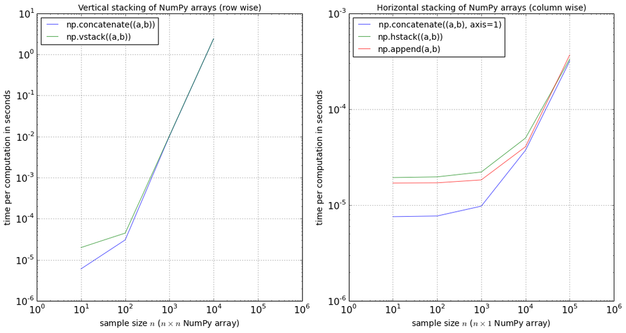

```python
plot()
```

```python
%watermark
```

```
05/07/2014 19:18:43

CPython 3.4.1
IPython 2.1.0

compiler   : GCC 4.2.1 (Apple Inc. build 5577)
system     : Darwin
release    : 13.2.0
machine    : x86_64
processor  : i386
CPU cores  : 2
interpreter: 64bit
```

The plots above are indicating that the `concatenate` functions are indeed faster to call for small sample sizes. However, large arrays are the ones where performance really matters, and we can see that the other functions are catching up performance-wise with increasing array sizes.